# Oceanographic geographical features data

[figure not shown]

### 1.Seabed Habitats Mapping around Ireland

Since 1999, the vast seabed off the Irish coast has been mapped acoustically by two pioneering projects: INSS and INFOMAR. The most up-to-date data of seabed substrate/broad habitat in Irish waters provided by INFOMAR.

https://www.infomar.ie/maps/interactive-maps/seabed-and-sediment

[interactive chart not shown]

MSFD_BBHT_Ireland2019

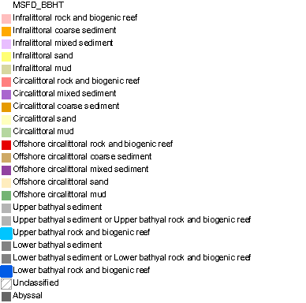

The data are in shapefile format and can be summarized by the following attributes.

#### Attributes

| Biozone | Substrate | Folk_5 | EUNIS | MSFD_BBHT |
| --- | --- | --- | --- | --- |
| Atlantic lower abyssal | Biogenic reef | Coarse sediment | A3: Infralittoral rock and other hard substrata | Abyssal |
| Atlantic lower bathyal | Coarse sediment | Mixed sediment | A4: Circalittoral rock and other hard substrata | Circalittoral coarse sediment |
| Atlantic mid abyssal | Coarse substrate | Mud to muddy Sand | A5.13: Infralittoral coarse sediment | Circalittoral mixed sediment |
| Atlantic mid bathyal | Fine mud | Rock | A5.14: Circalittoral coarse sediment | Circalittoral mud |
| Atlantic upper abyssal | Mixed sediment | Sand | A5.15: Deep circalittoral coarse sediment | Circalittoral rock and biogenic reef |
| Atlantic upper bathyal | Mud | Unclassified | A5.23 or A5.24: Infralittoral fine sand or Infralittoral muddy sand | Circalittoral sand |
| Atlanto-Mediterranean mid bathyal | Muddy sand |  | A5.25 or A5.26: Circalittoral fine sand or Circalittoral muddy sand | Infralittoral coarse sediment |
| Deep circalittoral | Rock |  | A5.27: Deep circalittoral sand | Infralittoral mixed sediment |
| Infralittoral | Rock or other hard substrata |  | A5.33: Infralittoral sandy mud | Infralittoral mud |
| Shallow circalittoral | Sand |  | A5.34: Infralittoral fine mud | Infralittoral rock and biogenic reef |
| Unclassified | Sandy mud |  | A5.35: Circalittoral sandy mud | Infralittoral sand |
| Upper bathyal | Sandy mud or Muddy sand |  | A5.36: Circalittoral fine mud | Lower bathyal rock and biogenic reef |
|  | sandy Mud/muddy Sand |  | A5.37: Deep circalittoral mud | Lower bathyal sediment |
|  | Seabed |  | A5.44: Circalittoral mixed sediments | Lower bathyal sediment or Lower bathyal rock and biogenic reef |
|  | Unclassified substrate |  | A5.45: Deep circalittoral mixed sediments | Offshore circalittoral coarse sediment |
|  | Unclassiifed substrate |  | A6.11: Deep-sea rock | Offshore circalittoral mixed sediment |
|  |  |  | A6.2: Deep-sea mixed substrata | Offshore circalittoral mud |
|  |  |  | A6.3 Deep-sea sand or A6.4 Deep-sea muddy sand | Offshore circalittoral rock and biogenic reef |
|  |  |  | A6.5: Deep-sea mud | Offshore circalittoral sand |
|  |  |  | A6.72: Seamounts, knolls and banks | Unclassified |
|  |  |  | A6.75: Carbonate mounds | Upper bathyal rock and biogenic reef |
|  |  |  | A6: Deep-sea bed | Upper bathyal sediment |
|  |  |  | Unclassified | Upper bathyal sediment or Upper bathyal rock and biogenic reef |

### 2. Copernicus Marine Service Data

Avialable to download: http://marine.copernicus.eu/services-portfolio/access-to-products/?option=com_csw&task=results

Exhaustive list of Acronyms and Abbreviations. http://marine.copernicus.eu/glossary/

*Regional Domain:* Iberia-Biscay-Ireland Regional Seas with subsetting

#### Temperature, Velocity and Salinity

##### **Ocean Physics Reanalysis**

*Overview:*

The IBI (Iberian Biscay Irish) Ocean Reanalysis system provides 3D monthly and daily ocean fields, as well as hourly mean values for some surface variables, since 01/01/1992. Monthly and daily averages of 3D Temperature, Salinity, Mix Layer Depth, Sea Bottom Temperature, Zonal and Meridional Velocity components and Sea Surface Height are provided. Hourly means of surface fields for variables such as Sea Surface Height, Mix Layer Depth, Surface Temperature and Currents, together with Barotropic Velocities are also provided. The IBI model numerical core is based on the NEMO v3.6 ocean general circulation model run at 1/12° horizontal resolution.Altimeter data, in situ temperature and salinity vertical profiles and satellite sea surface temperature are assimilated.

*Geographical Covarage:* Lon: from 56 till 48, Lat: from -18 till -2

*Observation or Models:* Numerical Model

*Temporial Coverage:* from 1992-01-16 to 2018-12-16

*Temporial Resolution:* monthly mean

*Original File format:* NetCDF-3

*Variables:*

Variables Description

| Name | Description | Standard.Name | Units |
| --- | --- | --- | --- |
| thetao | Temperature | sea_water_potential_temperature | degrees_C |
| bottomT | Sea floor potential temperature | sea_water_potential_temperature_at_sea_floor | degrees_C |
| so | Salinity | sea_water_salinity | 1.00E-03 |
| zos | Sea surface height | sea_surface_height_above_geoid | m |
| uo | Eastward velocity | eastward_sea_water_velocity | m s-1 |
| vo | Northward velocity | northward_sea_water_velocity | m s-1 |
| mlotst | Ocean mixed layer thickness defined by density | ocean_mixed_layer_thickness_defined_by_sigma_theta | m |

#### Nutrients, Oxygen and Plankton

##### **Ocean BioGeoChemistry NON ASSIMILATIVE Hindcast**

*Overview:*

The IBI-MFC provides a 3D high-resolution biogeochemical multi-year product starting on 01/01/1992. To this aim, an application of the biogeochemical model PISCES is run simultaneously with the ocean physical IBI reanalysis, generating both products at the same 1/12° horizontal resolution. The PISCES model is able to simulate the first levels of the marine food web, from nutrients up to mesozooplankton and it has 24 state variables. The main biogeochemical variables, such as chlorophyll, oxygen, iron, nitrate, ammonium, phosphate, silicate, net primary production and the euphotic zone depth, are distributed as part of this IBI biogeochemical multi-year product.

*Observation or Models:* Numerical Model

*Temporial Coverage:* from 1992-01-16 to 2018-12-16

*Temporial Resolution:* monthly mean

*Original File format:* N/A

*Variables:*

Variables Description

| Name | Description | Standard.Name | Units |
| --- | --- | --- | --- |
| chl | Mass Concentration of Chlorophyll in Sea Water | mass_concentration_of_chlorophyll_a_in_sea_water | mg.m-3 |
| phyc | Mole Concentration of Phytoplankton Expressed as Carbon in Sea Water | mole_concentration_of_phytoplankton_expressed_as_carbon_in_sea_water | mmol.m-3 |
| o2 | Mole Concentration of Dissolved Oxygen in Sea Water | mole_concentration_of_dissolved_molecular_oxygen_in_sea_water | mmol.m-3 |
| no3 | Mole Concentration of Nitrate in Sea Water | mole_concentration_of_nitrate_in_sea_water | mmol.m-3 |
| po4 | Mole Concentration of Phosphate in Sea Water | mole_concentration_of_phosphate_in_sea_water | mmol.m-3 |
| si | Mole Concentration of Silicate in Sea Water | mole_concentration_of_silicate_in_sea_water | mmol.m-3 |
| fe | Mole Concentration of Iron in Sea Water | mole_concentration_of_dissolved_iron_in_sea_water | mmol.m-3 |
| nh4 | Mole Concentration of Ammonium in Sea Water | mole_concentration_of_ammonium_in_sea_water | mmol.m-3 |
| nppv | Net Primary Productivity of Carbon | net_primary_production_of_biomass_expressed_as_carbon_per_unit_volume_in_sea_water | mg.m-3.day-1 |
| zeu | Euphotic Zone Depth | euphotic_zone_depth | m |

### 3. An operational zooplankton data service

*Interactive Mapping:*

OOPS - Copepods: ICES Operational Oceanographic Products and Services - Gridded Copepod abundance data; European Marine Observation Data Network (EMODnet) Biology project.

http://gis.ices.dk/sf/index.html?widget=oops-z

*Data product:*

The EMODnet products include a set of gridded map layers showing the average abundance of marine species for different time windows (seasonal, annual) using geospatial modelling. The spatial modelling tool used to calculate the gridded abundance maps is based on DIVA described at the following link

https://www.emodnet-biology.eu/blog/oops

and abundance data for 1 year and 10 years bin available to download from

https://www.emodnet-biology.eu/documents#elf_l1_RGF0YV9wcm9kdWN0c1xPT1BT as zip file for

- 6 copepod species: Acartia spp, Oithona spp, Metridia lucens, Temora longicornis, Calanus helgolandicus, Calanus finmarchicus
- large copepod species
- small copepod species

with

*Temporial Coverage:* from 1958-Jan_March to 2013-Oct_Dec

Avialable data were manipulated and subsetted to

*Geographical Covarage:* Lon: from 56 till 48, Lat: from -18 till -2

and saved to

*Original File format:* NetCDF-3

for all six species, large and small copepod with 1 and 10 years bin.

*Variables:*

Variables

| Name | Description | Units |
| --- | --- | --- |
| Ab | Abundance | log-transformed |
| Ab_L1 | Abundance masked using a relative error threshold of 0.3 | log-transformed |
| Ab_L2 | Abundance masked using a relative error threshold of 0.5 | log-transformed |